# Assignment4_AppliedGenomics

shaistamadad

4/5/2020

PART A, RNA-seq: You will use the same dataset from the previous assignment. You will perform an alternative splicing analysis, comparing mouse brain (hippocampus) cells treated by potassium chloride (KS) as a control and norepinephrine (NS) as experimental perturbation (4 biological replicates in each group). It uses paired end data: 101 bp x 2. It is a two independent sample experimental design. The data has been mapped and exon level counts have been computed for you and are available in the file “HW2_mouse_brain_RNAseq_exonlevel_counts.Rdata”. For this exon dataset the variable “counts” has the counts and “gene_annotation” has gene annotation information. The experimental design- a simple two independent sample design- is described in the tab-delimited text file “hw2_exp_design.tsv”.

#Perform the following steps of an RNA-seq analysis: ##(1) Do an exon-level differential splicing analysis using limma. ##(2) Generate exon plots for the top 5 genes showing statistical evidence of alternative splicing. Save as “splicing_plots_NETID.pdf”.

```r
library("dplyr")  # for arrange() function
library(limma)    # main limma package
library(edgeR)    # we need the TMM function from edgeR
load(file=paste("HW2_mouse_brain_RNAseq_exonlevel_counts.RData",sep=""))   #load the file
```

```r
exp_design<- read.delim("hw2_exp_design.tsv")  #will need this for the exon-level differentiation step using limma
```

```r
DGE <- DGEList(counts=counts, genes=gene_annotation)  # convert the exon countot into a DGE list format which is suitable to use with limma
```

```r
DGE <- calcNormFactors(DGE)   #TMM normalisation step
```

```r
# non-specific filter to remove low count features
# (requires > 1 counts over at least 1 samples)
#note that despite keeping the filter very low, only 36 percent of the counts remain
isexpr <- rowSums(DGE$counts > 1) >=1
# check what fraction of exons remain
sum(isexpr)/nrow(DGE)
```

```
## [1] 0.3687545
```

```r
DGE <- DGE[isexpr,,keep.lib.sizes=FALSE]  #only keep the counts in the DGE list which fit the filtering criteria above
dim(DGE)
```

```
## [1] 119902      8
```

```r
design <- model.matrix(~stressor, data=exp_design)
```

In the design matrix, intercept is mean stressor KS and StressorNS is StressorNS- Stressor KS

# Calculate weights to correct for Poisson count noise due to discrete nature of RNA-seq. This is done by empirically fitting the curve.

# This allows us to use a weighted linear model rather than requiring a complex generalized linear model of a negative binomial distribution.

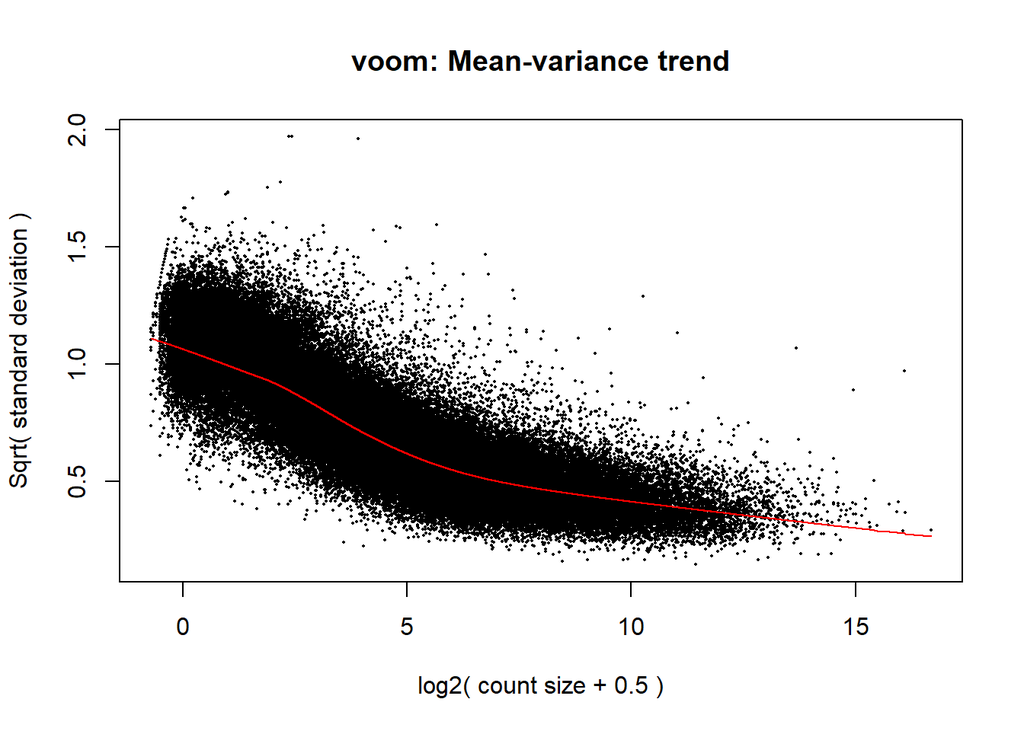

```r
v <- voom(DGE,design,plot=TRUE)
```

```r
fit <- lmFit(v,design)  # lmFit fits linear model across all genes
```

# Tests for differential exon usage for each gene and for each column of fit

We will find differentially expressed exons, using the same approach as for differential gene expression

```r
fit3_splice <- diffSplice(fit, geneid="GeneID")
```

```
## Total number of exons:  119902
## Total number of genes:  17659
## Number of genes with 1 exon:  4528
## Mean number of exons in a gene:  7
## Max number of exons in a gene:  116
```

Rank genes by combining exon-level p-values into an overall measure of differential gene splicing activity (e.g. by an F-test, or combined pvalues using Simes or other methods). This approach is provided by the limma package.

#Top table ranking the most differentially spliced genes or exons

```r
colnames(fit3_splice) # show the column names of comparisons
```

```
## [1] "(Intercept)" "stressorNS"
```

```r
FC_splice = topSplice(fit3_splice, coef="stressorNS", number=nrow(DGE$counts)) # ranks the genes showing splicing from lowed p value at the top, to the highest p value at the bottom
```

```r
head(FC_splice)
```

```
##                          GeneID Strand NExons      P.Value          FDR
## Gpld1.25                  Gpld1      +     26 9.248059e-23 1.214363e-18
## Elmo1.16                  Elmo1      +     17 4.070894e-16 2.672745e-12
## Tnr.22                      Tnr      +     23 8.847362e-13 3.872490e-09
## X9330182L06Rik.21 9330182L06Rik      +     22 1.426251e-11 4.682026e-08
## Nav2.2                     Nav2      +      3 4.564512e-08 1.198732e-04
## Snx12.3                   Snx12      -      3 5.353270e-07 9.621258e-04
```

```r
# Get the top 5 genes showing significance for alternatie splicing
pdf("splicing_plots_sm8847.pdf")   # save plots to pdf
for (i in 1:5) {  # plot top 5 genes
plotSplice(fit3_splice, coef="stressorNS", geneid=FC_splice$GeneID[i])
}
dev.off()
```